# Risk Factor Analysis

## Outcome Variable

**Outcome Variable:** wasted

## Predictor Variables

**Intervention Variable:** mage

**Adjustment Set:**

- arm
- meducyrs
- feducyrs
- W_mhtcm
- single
- delta_meducyrs
- delta_feducyrs
- delta_W_mhtcm
- delta_single

## Stratifying Variables

The analysis was stratified on these variable(s):

- agecat
- studyid
- country

## Data Summary

| agecat | studyid | country | mage | wasted | n_cell | n |
| --- | --- | --- | --- | --- | --- | --- |
| Birth | ki0047075b-MAL-ED | BANGLADESH | [20-30) | 0 | 143 | 241 |
| Birth | ki0047075b-MAL-ED | BANGLADESH | [20-30) | 1 | 21 | 241 |
| Birth | ki0047075b-MAL-ED | BANGLADESH | <20 | 0 | 24 | 241 |
| Birth | ki0047075b-MAL-ED | BANGLADESH | <20 | 1 | 10 | 241 |
| Birth | ki0047075b-MAL-ED | BANGLADESH | >=30 | 0 | 34 | 241 |
| Birth | ki0047075b-MAL-ED | BANGLADESH | >=30 | 1 | 9 | 241 |
| Birth | ki0047075b-MAL-ED | BRAZIL | [20-30) | 0 | 106 | 183 |
| Birth | ki0047075b-MAL-ED | BRAZIL | [20-30) | 1 | 4 | 183 |
| Birth | ki0047075b-MAL-ED | BRAZIL | <20 | 0 | 34 | 183 |
| Birth | ki0047075b-MAL-ED | BRAZIL | <20 | 1 | 0 | 183 |
| Birth | ki0047075b-MAL-ED | BRAZIL | >=30 | 0 | 37 | 183 |
| Birth | ki0047075b-MAL-ED | BRAZIL | >=30 | 1 | 2 | 183 |
| Birth | ki0047075b-MAL-ED | INDIA | [20-30) | 0 | 136 | 202 |
| Birth | ki0047075b-MAL-ED | INDIA | [20-30) | 1 | 27 | 202 |
| Birth | ki0047075b-MAL-ED | INDIA | <20 | 0 | 20 | 202 |
| Birth | ki0047075b-MAL-ED | INDIA | <20 | 1 | 4 | 202 |
| Birth | ki0047075b-MAL-ED | INDIA | >=30 | 0 | 13 | 202 |
| Birth | ki0047075b-MAL-ED | INDIA | >=30 | 1 | 2 | 202 |
| Birth | ki0047075b-MAL-ED | NEPAL | [20-30) | 0 | 112 | 168 |
| Birth | ki0047075b-MAL-ED | NEPAL | [20-30) | 1 | 17 | 168 |
| Birth | ki0047075b-MAL-ED | NEPAL | <20 | 0 | 4 | 168 |
| Birth | ki0047075b-MAL-ED | NEPAL | <20 | 1 | 0 | 168 |
| Birth | ki0047075b-MAL-ED | NEPAL | >=30 | 0 | 32 | 168 |
| Birth | ki0047075b-MAL-ED | NEPAL | >=30 | 1 | 3 | 168 |
| Birth | ki0047075b-MAL-ED | PERU | [20-30) | 0 | 139 | 279 |
| Birth | ki0047075b-MAL-ED | PERU | [20-30) | 1 | 3 | 279 |
| Birth | ki0047075b-MAL-ED | PERU | <20 | 0 | 71 | 279 |
| Birth | ki0047075b-MAL-ED | PERU | <20 | 1 | 2 | 279 |
| Birth | ki0047075b-MAL-ED | PERU | >=30 | 0 | 63 | 279 |
| Birth | ki0047075b-MAL-ED | PERU | >=30 | 1 | 1 | 279 |

[output cut: 378 more lines]

The following strata were considered:

- agecat: 24 months, studyid: ki0047075b-MAL-ED, country: BANGLADESH
- agecat: 24 months, studyid: ki0047075b-MAL-ED, country: BRAZIL
- agecat: 24 months, studyid: ki0047075b-MAL-ED, country: INDIA
- agecat: 24 months, studyid: ki0047075b-MAL-ED, country: NEPAL
- agecat: 24 months, studyid: ki0047075b-MAL-ED, country: PERU
- agecat: 24 months, studyid: ki0047075b-MAL-ED, country: SOUTH AFRICA
- agecat: 24 months, studyid: ki0047075b-MAL-ED, country: TANZANIA, UNITED REPUBLIC OF
- agecat: 24 months, studyid: ki1000108-CMC-V-BCS-2002, country: INDIA
- agecat: 24 months, studyid: ki1000108-IRC, country: INDIA
- agecat: 24 months, studyid: ki1017093-NIH-Birth, country: BANGLADESH
- agecat: 24 months, studyid: ki1017093b-PROVIDE, country: BANGLADESH
- agecat: 24 months, studyid: ki1017093c-NIH-Crypto, country: BANGLADESH
- agecat: 24 months, studyid: ki1066203-TanzaniaChild2, country: TANZANIA, UNITED REPUBLIC OF
- agecat: 24 months, studyid: ki1101329-Keneba, country: GAMBIA
- agecat: 24 months, studyid: ki1113344-GMS-Nepal, country: NEPAL
- agecat: 24 months, studyid: ki1119695-PROBIT, country: BELARUS
- agecat: 24 months, studyid: ki1126311-ZVITAMBO, country: ZIMBABWE
- agecat: 24 months, studyid: ki1135781-COHORTS, country: GUATEMALA
- agecat: 24 months, studyid: ki1135781-COHORTS, country: INDIA
- agecat: 24 months, studyid: ki1135781-COHORTS, country: PHILIPPINES
- agecat: 24 months, studyid: ki1148112-LCNI-5, country: MALAWI
- agecat: 24 months, studyid: kiGH5241-JiVitA-3, country: BANGLADESH
- agecat: 6 months, studyid: ki0047075b-MAL-ED, country: BANGLADESH
- agecat: 6 months, studyid: ki0047075b-MAL-ED, country: BRAZIL
- agecat: 6 months, studyid: ki0047075b-MAL-ED, country: INDIA
- agecat: 6 months, studyid: ki0047075b-MAL-ED, country: NEPAL
- agecat: 6 months, studyid: ki0047075b-MAL-ED, country: PERU
- agecat: 6 months, studyid: ki0047075b-MAL-ED, country: SOUTH AFRICA
- agecat: 6 months, studyid: ki0047075b-MAL-ED, country: TANZANIA, UNITED REPUBLIC OF
- agecat: 6 months, studyid: ki1000108-CMC-V-BCS-2002, country: INDIA
- agecat: 6 months, studyid: ki1000108-IRC, country: INDIA
- agecat: 6 months, studyid: ki1000109-EE, country: PAKISTAN
- agecat: 6 months, studyid: ki1000304b-SAS-CompFeed, country: INDIA
- agecat: 6 months, studyid: ki1000304b-SAS-FoodSuppl, country: INDIA
- agecat: 6 months, studyid: ki1017093-NIH-Birth, country: BANGLADESH
- agecat: 6 months, studyid: ki1017093b-PROVIDE, country: BANGLADESH
- agecat: 6 months, studyid: ki1017093c-NIH-Crypto, country: BANGLADESH
- agecat: 6 months, studyid: ki1066203-TanzaniaChild2, country: TANZANIA, UNITED REPUBLIC OF
- agecat: 6 months, studyid: ki1101329-Keneba, country: GAMBIA
- agecat: 6 months, studyid: ki1112895-Guatemala BSC, country: GUATEMALA
- agecat: 6 months, studyid: ki1113344-GMS-Nepal, country: NEPAL
- agecat: 6 months, studyid: ki1119695-PROBIT, country: BELARUS
- agecat: 6 months, studyid: ki1126311-ZVITAMBO, country: ZIMBABWE
- agecat: 6 months, studyid: ki1135781-COHORTS, country: GUATEMALA
- agecat: 6 months, studyid: ki1135781-COHORTS, country: INDIA
- agecat: 6 months, studyid: ki1135781-COHORTS, country: PHILIPPINES
- agecat: 6 months, studyid: ki1148112-LCNI-5, country: MALAWI
- agecat: 6 months, studyid: kiGH5241-JiVitA-3, country: BANGLADESH
- agecat: Birth, studyid: ki0047075b-MAL-ED, country: BANGLADESH
- agecat: Birth, studyid: ki0047075b-MAL-ED, country: BRAZIL
- agecat: Birth, studyid: ki0047075b-MAL-ED, country: INDIA
- agecat: Birth, studyid: ki0047075b-MAL-ED, country: NEPAL
- agecat: Birth, studyid: ki0047075b-MAL-ED, country: PERU
- agecat: Birth, studyid: ki0047075b-MAL-ED, country: SOUTH AFRICA
- agecat: Birth, studyid: ki0047075b-MAL-ED, country: TANZANIA, UNITED REPUBLIC OF
- agecat: Birth, studyid: ki1000108-CMC-V-BCS-2002, country: INDIA
- agecat: Birth, studyid: ki1000108-IRC, country: INDIA
- agecat: Birth, studyid: ki1000109-EE, country: PAKISTAN
- agecat: Birth, studyid: ki1000304b-SAS-CompFeed, country: INDIA
- agecat: Birth, studyid: ki1017093-NIH-Birth, country: BANGLADESH
- agecat: Birth, studyid: ki1017093c-NIH-Crypto, country: BANGLADESH
- agecat: Birth, studyid: ki1101329-Keneba, country: GAMBIA
- agecat: Birth, studyid: ki1119695-PROBIT, country: BELARUS
- agecat: Birth, studyid: ki1126311-ZVITAMBO, country: ZIMBABWE
- agecat: Birth, studyid: ki1135781-COHORTS, country: GUATEMALA
- agecat: Birth, studyid: ki1135781-COHORTS, country: INDIA
- agecat: Birth, studyid: ki1135781-COHORTS, country: PHILIPPINES
- agecat: Birth, studyid: kiGH5241-JiVitA-3, country: BANGLADESH

### Dropped Strata

Some strata were dropped due to rare outcomes:

- agecat: Birth, studyid: ki0047075b-MAL-ED, country: BRAZIL
- agecat: Birth, studyid: ki0047075b-MAL-ED, country: INDIA
- agecat: Birth, studyid: ki0047075b-MAL-ED, country: NEPAL
- agecat: Birth, studyid: ki0047075b-MAL-ED, country: PERU
- agecat: Birth, studyid: ki0047075b-MAL-ED, country: SOUTH AFRICA
- agecat: Birth, studyid: ki0047075b-MAL-ED, country: TANZANIA, UNITED REPUBLIC OF
- agecat: Birth, studyid: ki1000108-CMC-V-BCS-2002, country: INDIA
- agecat: Birth, studyid: ki1000109-EE, country: PAKISTAN
- agecat: Birth, studyid: ki1000304b-SAS-CompFeed, country: INDIA
- agecat: Birth, studyid: ki1017093-NIH-Birth, country: BANGLADESH
- agecat: Birth, studyid: ki1017093c-NIH-Crypto, country: BANGLADESH
- agecat: Birth, studyid: ki1101329-Keneba, country: GAMBIA
- agecat: 6 months, studyid: ki0047075b-MAL-ED, country: BANGLADESH
- agecat: 6 months, studyid: ki0047075b-MAL-ED, country: BRAZIL
- agecat: 6 months, studyid: ki0047075b-MAL-ED, country: INDIA
- agecat: 6 months, studyid: ki0047075b-MAL-ED, country: NEPAL
- agecat: 6 months, studyid: ki0047075b-MAL-ED, country: PERU
- agecat: 6 months, studyid: ki0047075b-MAL-ED, country: SOUTH AFRICA
- agecat: 6 months, studyid: ki0047075b-MAL-ED, country: TANZANIA, UNITED REPUBLIC OF
- agecat: 6 months, studyid: ki1000108-CMC-V-BCS-2002, country: INDIA
- agecat: 6 months, studyid: ki1000109-EE, country: PAKISTAN
- agecat: 6 months, studyid: ki1000304b-SAS-FoodSuppl, country: INDIA
- agecat: 6 months, studyid: ki1017093-NIH-Birth, country: BANGLADESH
- agecat: 6 months, studyid: ki1017093b-PROVIDE, country: BANGLADESH
- agecat: 6 months, studyid: ki1017093c-NIH-Crypto, country: BANGLADESH
- agecat: 6 months, studyid: ki1112895-Guatemala BSC, country: GUATEMALA
- agecat: 6 months, studyid: ki1135781-COHORTS, country: GUATEMALA
- agecat: 6 months, studyid: ki1148112-LCNI-5, country: MALAWI
- agecat: 24 months, studyid: ki0047075b-MAL-ED, country: BANGLADESH
- agecat: 24 months, studyid: ki0047075b-MAL-ED, country: BRAZIL
- agecat: 24 months, studyid: ki0047075b-MAL-ED, country: INDIA
- agecat: 24 months, studyid: ki0047075b-MAL-ED, country: NEPAL
- agecat: 24 months, studyid: ki0047075b-MAL-ED, country: PERU
- agecat: 24 months, studyid: ki0047075b-MAL-ED, country: SOUTH AFRICA
- agecat: 24 months, studyid: ki0047075b-MAL-ED, country: TANZANIA, UNITED REPUBLIC OF
- agecat: 24 months, studyid: ki1000108-CMC-V-BCS-2002, country: INDIA
- agecat: 24 months, studyid: ki1000108-IRC, country: INDIA
- agecat: 24 months, studyid: ki1017093-NIH-Birth, country: BANGLADESH
- agecat: 24 months, studyid: ki1066203-TanzaniaChild2, country: TANZANIA, UNITED REPUBLIC OF
- agecat: 24 months, studyid: ki1119695-PROBIT, country: BELARUS
- agecat: 24 months, studyid: ki1148112-LCNI-5, country: MALAWI

## Methods Detail

We’re interested in the causal parameters $E[Y_a]$ for all values of $a \in \mathcal{A}$. These parameters represent the mean outcome if, possibly contrary to fact, we intervened to set all units to have $A=a$. Under the randomization and positivity assumptions, these are identified by the statistical parameters $\psi_a=E_W[E_{Y|A,W}(Y|A=a,W)]$. In addition, we’re interested in the mean of $Y$, $E[Y]$ under no intervention (the observed mean). We will estimate these parameters by using SuperLearner to fit the relevant likelihood factors – $E_{Y|A,W}(Y|A=a,W)$ and $p(A=a|W)$, and then updating our likelihood fit using a joint TMLE.

For unadjusted analyses ($W=\{\}$), initial likelihoods were estimated using Lrnr_glm to estimate the simple $E(Y|A)$ and Lrnr_mean to estimate $p(A)$. For adjusted analyses, a small library containing Lrnr_glmnet, Lrnr_xgboost, and Lrnr_mean was used.

Having estimated these parameters, we will then use the delta method to estimate relative risks and attributable risks relative to a prespecified baseline level of $A$.

# Results Detail

## Results Plots

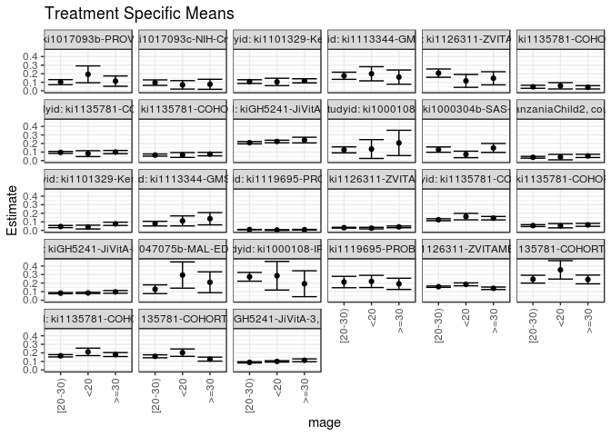

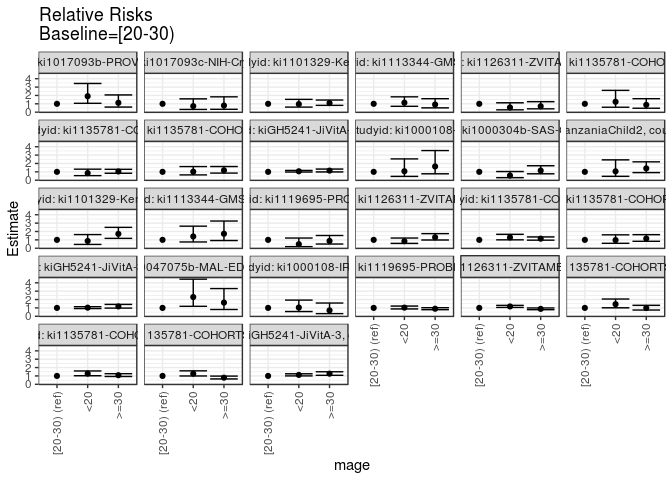

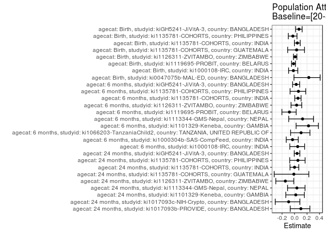

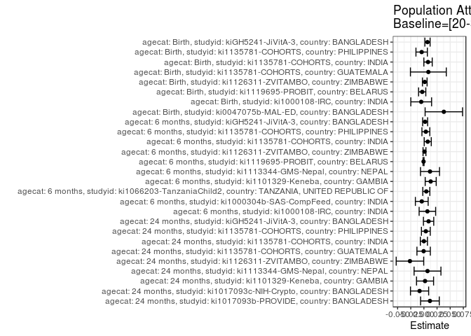

## Results Table

### Parameter: TSM

| agecat | studyid | country | intervention_level | baseline_level | estimate | ci_lower | ci_upper |
| --- | --- | --- | --- | --- | --- | --- | --- |
| Birth | ki0047075b-MAL-ED | BANGLADESH | [20-30) | NA | 0.1280488 | 0.0768024 | 0.1792951 |
| Birth | ki0047075b-MAL-ED | BANGLADESH | <20 | NA | 0.2941176 | 0.1406424 | 0.4475929 |
| Birth | ki0047075b-MAL-ED | BANGLADESH | >=30 | NA | 0.2093023 | 0.0874570 | 0.3311477 |
| Birth | ki1000108-IRC | INDIA | [20-30) | NA | 0.2733564 | 0.2218977 | 0.3248151 |
| Birth | ki1000108-IRC | INDIA | <20 | NA | 0.2857143 | 0.1181409 | 0.4532877 |
| Birth | ki1000108-IRC | INDIA | >=30 | NA | 0.1923077 | 0.0405968 | 0.3440186 |
| Birth | ki1119695-PROBIT | BELARUS | [20-30) | NA | 0.2121517 | 0.1456630 | 0.2786404 |
| Birth | ki1119695-PROBIT | BELARUS | <20 | NA | 0.2193129 | 0.1477230 | 0.2909028 |
| Birth | ki1119695-PROBIT | BELARUS | >=30 | NA | 0.1910454 | 0.1254210 | 0.2566698 |
| Birth | ki1126311-ZVITAMBO | ZIMBABWE | [20-30) | NA | 0.1576497 | 0.1499597 | 0.1653396 |
| Birth | ki1126311-ZVITAMBO | ZIMBABWE | <20 | NA | 0.1850384 | 0.1680306 | 0.2020463 |
| Birth | ki1126311-ZVITAMBO | ZIMBABWE | >=30 | NA | 0.1390735 | 0.1244342 | 0.1537129 |
| Birth | ki1135781-COHORTS | GUATEMALA | [20-30) | NA | 0.2454812 | 0.1996998 | 0.2912626 |
| Birth | ki1135781-COHORTS | GUATEMALA | <20 | NA | 0.3545321 | 0.2470123 | 0.4620519 |
| Birth | ki1135781-COHORTS | GUATEMALA | >=30 | NA | 0.2421187 | 0.1906746 | 0.2935629 |
| Birth | ki1135781-COHORTS | INDIA | [20-30) | NA | 0.1655859 | 0.1521686 | 0.1790032 |
| Birth | ki1135781-COHORTS | INDIA | <20 | NA | 0.2113611 | 0.1679339 | 0.2547882 |
| Birth | ki1135781-COHORTS | INDIA | >=30 | NA | 0.1801937 | 0.1571350 | 0.2032524 |
| Birth | ki1135781-COHORTS | PHILIPPINES | [20-30) | NA | 0.1598627 | 0.1425025 | 0.1772229 |
| Birth | ki1135781-COHORTS | PHILIPPINES | <20 | NA | 0.2027048 | 0.1594677 | 0.2459418 |
| Birth | ki1135781-COHORTS | PHILIPPINES | >=30 | NA | 0.1267362 | 0.1033797 | 0.1500927 |
| Birth | kiGH5241-JiVitA-3 | BANGLADESH | [20-30) | NA | 0.0890504 | 0.0819128 | 0.0961879 |
| Birth | kiGH5241-JiVitA-3 | BANGLADESH | <20 | NA | 0.1000493 | 0.0920219 | 0.1080768 |
| Birth | kiGH5241-JiVitA-3 | BANGLADESH | >=30 | NA | 0.1130374 | 0.0963652 | 0.1297097 |
| 6 months | ki1000108-IRC | INDIA | [20-30) | NA | 0.1257310 | 0.0905497 | 0.1609123 |
| 6 months | ki1000108-IRC | INDIA | <20 | NA | 0.1351351 | 0.0248446 | 0.2454257 |
| 6 months | ki1000108-IRC | INDIA | >=30 | NA | 0.2068966 | 0.0592839 | 0.3545092 |
| 6 months | ki1000304b-SAS-CompFeed | INDIA | [20-30) | NA | 0.1285052 | 0.0975313 | 0.1594791 |
| 6 months | ki1000304b-SAS-CompFeed | INDIA | <20 | NA | 0.0720846 | 0.0339172 | 0.1102520 |
| 6 months | ki1000304b-SAS-CompFeed | INDIA | >=30 | NA | 0.1478792 | 0.0956202 | 0.2001383 |

[output cut: 51 more lines]

### Parameter: E(Y)

| agecat | studyid | country | intervention_level | baseline_level | estimate | ci_lower | ci_upper |
| --- | --- | --- | --- | --- | --- | --- | --- |
| Birth | ki0047075b-MAL-ED | BANGLADESH | NA | NA | 0.1659751 | 0.1189041 | 0.2130461 |
| Birth | ki1000108-IRC | INDIA | NA | NA | 0.2682216 | 0.2212677 | 0.3151755 |
| Birth | ki1119695-PROBIT | BELARUS | NA | NA | 0.2089120 | 0.1435514 | 0.2742726 |
| Birth | ki1126311-ZVITAMBO | ZIMBABWE | NA | NA | 0.1592391 | 0.1529198 | 0.1655584 |
| Birth | ki1135781-COHORTS | GUATEMALA | NA | NA | 0.2539683 | 0.2229196 | 0.2850169 |
| Birth | ki1135781-COHORTS | INDIA | NA | NA | 0.1734393 | 0.1622569 | 0.1846217 |
| Birth | ki1135781-COHORTS | PHILIPPINES | NA | NA | 0.1555709 | 0.1423748 | 0.1687670 |
| Birth | kiGH5241-JiVitA-3 | BANGLADESH | NA | NA | 0.0958477 | 0.0906460 | 0.1010493 |
| 6 months | ki1000108-IRC | INDIA | NA | NA | 0.1323529 | 0.0994307 | 0.1652752 |
| 6 months | ki1000304b-SAS-CompFeed | INDIA | NA | NA | 0.1244378 | 0.0992652 | 0.1496104 |
| 6 months | ki1066203-TanzaniaChild2 | TANZANIA, UNITED REPUBLIC OF | NA | NA | 0.0432621 | 0.0343680 | 0.0521561 |
| 6 months | ki1101329-Keneba | GAMBIA | NA | NA | 0.0576923 | 0.0476698 | 0.0677148 |
| 6 months | ki1113344-GMS-Nepal | NEPAL | NA | NA | 0.0905861 | 0.0668565 | 0.1143158 |
| 6 months | ki1119695-PROBIT | BELARUS | NA | NA | 0.0082503 | 0.0066012 | 0.0098994 |
| 6 months | ki1126311-ZVITAMBO | ZIMBABWE | NA | NA | 0.0321251 | 0.0283197 | 0.0359306 |
| 6 months | ki1135781-COHORTS | INDIA | NA | NA | 0.1321217 | 0.1226366 | 0.1416069 |
| 6 months | ki1135781-COHORTS | PHILIPPINES | NA | NA | 0.0594974 | 0.0505830 | 0.0684118 |
| 6 months | kiGH5241-JiVitA-3 | BANGLADESH | NA | NA | 0.0846892 | 0.0798858 | 0.0894926 |
| 24 months | ki1017093b-PROVIDE | BANGLADESH | NA | NA | 0.1124567 | 0.0866788 | 0.1382347 |
| 24 months | ki1017093c-NIH-Crypto | BANGLADESH | NA | NA | 0.0875486 | 0.0630907 | 0.1120065 |
| 24 months | ki1101329-Keneba | GAMBIA | NA | NA | 0.1096210 | 0.0948307 | 0.1244113 |
| 24 months | ki1113344-GMS-Nepal | NEPAL | NA | NA | 0.1827309 | 0.1487560 | 0.2167058 |
| 24 months | ki1126311-ZVITAMBO | ZIMBABWE | NA | NA | 0.1800948 | 0.1433886 | 0.2168010 |
| 24 months | ki1135781-COHORTS | GUATEMALA | NA | NA | 0.0464684 | 0.0338852 | 0.0590516 |
| 24 months | ki1135781-COHORTS | INDIA | NA | NA | 0.0957708 | 0.0862423 | 0.1052993 |
| 24 months | ki1135781-COHORTS | PHILIPPINES | NA | NA | 0.0681911 | 0.0582056 | 0.0781766 |
| 24 months | kiGH5241-JiVitA-3 | BANGLADESH | NA | NA | 0.2181903 | 0.2083363 | 0.2280442 |

### Parameter: RR

| agecat | studyid | country | intervention_level | baseline_level | estimate | ci_lower | ci_upper |
| --- | --- | --- | --- | --- | --- | --- | --- |
| Birth | ki0047075b-MAL-ED | BANGLADESH | [20-30) | [20-30) | 1.0000000 | 1.0000000 | 1.0000000 |
| Birth | ki0047075b-MAL-ED | BANGLADESH | <20 | [20-30) | 2.2969188 | 1.1899986 | 4.4334805 |
| Birth | ki0047075b-MAL-ED | BANGLADESH | >=30 | [20-30) | 1.6345515 | 0.8064786 | 3.3128696 |
| Birth | ki1000108-IRC | INDIA | [20-30) | [20-30) | 1.0000000 | 1.0000000 | 1.0000000 |
| Birth | ki1000108-IRC | INDIA | <20 | [20-30) | 1.0452080 | 0.5645305 | 1.9351651 |
| Birth | ki1000108-IRC | INDIA | >=30 | [20-30) | 0.7035054 | 0.3126330 | 1.5830697 |
| Birth | ki1119695-PROBIT | BELARUS | [20-30) | [20-30) | 1.0000000 | 1.0000000 | 1.0000000 |
| Birth | ki1119695-PROBIT | BELARUS | <20 | [20-30) | 1.0337549 | 0.8767595 | 1.2188624 |
| Birth | ki1119695-PROBIT | BELARUS | >=30 | [20-30) | 0.9005131 | 0.7901509 | 1.0262898 |
| Birth | ki1126311-ZVITAMBO | ZIMBABWE | [20-30) | [20-30) | 1.0000000 | 1.0000000 | 1.0000000 |
| Birth | ki1126311-ZVITAMBO | ZIMBABWE | <20 | [20-30) | 1.1737319 | 1.0577285 | 1.3024578 |
| Birth | ki1126311-ZVITAMBO | ZIMBABWE | >=30 | [20-30) | 0.8821682 | 0.7855680 | 0.9906473 |
| Birth | ki1135781-COHORTS | GUATEMALA | [20-30) | [20-30) | 1.0000000 | 1.0000000 | 1.0000000 |
| Birth | ki1135781-COHORTS | GUATEMALA | <20 | [20-30) | 1.4442333 | 1.0118452 | 2.0613921 |
| Birth | ki1135781-COHORTS | GUATEMALA | >=30 | [20-30) | 0.9863026 | 0.7437725 | 1.3079171 |
| Birth | ki1135781-COHORTS | INDIA | [20-30) | [20-30) | 1.0000000 | 1.0000000 | 1.0000000 |
| Birth | ki1135781-COHORTS | INDIA | <20 | [20-30) | 1.2764436 | 1.0234977 | 1.5919024 |
| Birth | ki1135781-COHORTS | INDIA | >=30 | [20-30) | 1.0882189 | 0.9352747 | 1.2661738 |
| Birth | ki1135781-COHORTS | PHILIPPINES | [20-30) | [20-30) | 1.0000000 | 1.0000000 | 1.0000000 |
| Birth | ki1135781-COHORTS | PHILIPPINES | <20 | [20-30) | 1.2679928 | 0.9981265 | 1.6108235 |
| Birth | ki1135781-COHORTS | PHILIPPINES | >=30 | [20-30) | 0.7927816 | 0.6401131 | 0.9818619 |
| Birth | kiGH5241-JiVitA-3 | BANGLADESH | [20-30) | [20-30) | 1.0000000 | 1.0000000 | 1.0000000 |
| Birth | kiGH5241-JiVitA-3 | BANGLADESH | <20 | [20-30) | 1.1235137 | 1.0051383 | 1.2558301 |
| Birth | kiGH5241-JiVitA-3 | BANGLADESH | >=30 | [20-30) | 1.2693652 | 1.0763641 | 1.4969729 |
| 6 months | ki1000108-IRC | INDIA | [20-30) | [20-30) | 1.0000000 | 1.0000000 | 1.0000000 |
| 6 months | ki1000108-IRC | INDIA | <20 | [20-30) | 1.0747957 | 0.4535482 | 2.5469971 |
| 6 months | ki1000108-IRC | INDIA | >=30 | [20-30) | 1.6455493 | 0.7646819 | 3.5411231 |
| 6 months | ki1000304b-SAS-CompFeed | INDIA | [20-30) | [20-30) | 1.0000000 | 1.0000000 | 1.0000000 |
| 6 months | ki1000304b-SAS-CompFeed | INDIA | <20 | [20-30) | 0.5609469 | 0.3039111 | 1.0353735 |
| 6 months | ki1000304b-SAS-CompFeed | INDIA | >=30 | [20-30) | 1.1507646 | 0.7656671 | 1.7295494 |

[output cut: 51 more lines]

### Parameter: PAR

| agecat | studyid | country | intervention_level | baseline_level | estimate | ci_lower | ci_upper |
| --- | --- | --- | --- | --- | --- | --- | --- |
| Birth | ki0047075b-MAL-ED | BANGLADESH | [20-30) | NA | 0.0379263 | 0.0023224 | 0.0735302 |
| Birth | ki1000108-IRC | INDIA | [20-30) | NA | -0.0051348 | -0.0248945 | 0.0146249 |
| Birth | ki1119695-PROBIT | BELARUS | [20-30) | NA | -0.0032397 | -0.0100920 | 0.0036126 |
| Birth | ki1126311-ZVITAMBO | ZIMBABWE | [20-30) | NA | 0.0015895 | -0.0028535 | 0.0060325 |
| Birth | ki1135781-COHORTS | GUATEMALA | [20-30) | NA | 0.0084871 | -0.0256259 | 0.0426001 |
| Birth | ki1135781-COHORTS | INDIA | [20-30) | NA | 0.0078534 | -0.0001064 | 0.0158132 |
| Birth | ki1135781-COHORTS | PHILIPPINES | [20-30) | NA | -0.0042918 | -0.0151402 | 0.0065566 |
| Birth | kiGH5241-JiVitA-3 | BANGLADESH | [20-30) | NA | 0.0067973 | 0.0018410 | 0.0117536 |
| 6 months | ki1000108-IRC | INDIA | [20-30) | NA | 0.0066219 | -0.0090812 | 0.0223251 |
| 6 months | ki1000304b-SAS-CompFeed | INDIA | [20-30) | NA | -0.0040674 | -0.0162266 | 0.0080917 |
| 6 months | ki1066203-TanzaniaChild2 | TANZANIA, UNITED REPUBLIC OF | [20-30) | NA | 0.0045377 | -0.0022040 | 0.0112794 |
| 6 months | ki1101329-Keneba | GAMBIA | [20-30) | NA | 0.0129290 | 0.0024841 | 0.0233739 |
| 6 months | ki1113344-GMS-Nepal | NEPAL | [20-30) | NA | 0.0116336 | -0.0064531 | 0.0297204 |
| 6 months | ki1119695-PROBIT | BELARUS | [20-30) | NA | -0.0006775 | -0.0016219 | 0.0002670 |
| 6 months | ki1126311-ZVITAMBO | ZIMBABWE | [20-30) | NA | 0.0010666 | -0.0016920 | 0.0038251 |
| 6 months | ki1135781-COHORTS | INDIA | [20-30) | NA | 0.0072918 | 0.0005807 | 0.0140028 |
| 6 months | ki1135781-COHORTS | PHILIPPINES | [20-30) | NA | 0.0037109 | -0.0037792 | 0.0112010 |
| 6 months | kiGH5241-JiVitA-3 | BANGLADESH | [20-30) | NA | 0.0022839 | -0.0024924 | 0.0070602 |
| 24 months | ki1017093b-PROVIDE | BANGLADESH | [20-30) | NA | 0.0114616 | -0.0063021 | 0.0292253 |
| 24 months | ki1017093c-NIH-Crypto | BANGLADESH | [20-30) | NA | -0.0082597 | -0.0255539 | 0.0090344 |
| 24 months | ki1101329-Keneba | GAMBIA | [20-30) | NA | 0.0021782 | -0.0140481 | 0.0184045 |
| 24 months | ki1113344-GMS-Nepal | NEPAL | [20-30) | NA | 0.0068634 | -0.0186666 | 0.0323934 |
| 24 months | ki1126311-ZVITAMBO | ZIMBABWE | [20-30) | NA | -0.0265473 | -0.0527189 | -0.0003756 |
| 24 months | ki1135781-COHORTS | GUATEMALA | [20-30) | NA | -0.0005241 | -0.0132499 | 0.0122017 |
| 24 months | ki1135781-COHORTS | INDIA | [20-30) | NA | -0.0000279 | -0.0067785 | 0.0067227 |
| 24 months | ki1135781-COHORTS | PHILIPPINES | [20-30) | NA | 0.0036876 | -0.0046815 | 0.0120566 |
| 24 months | kiGH5241-JiVitA-3 | BANGLADESH | [20-30) | NA | 0.0088922 | -0.0009202 | 0.0187045 |

### Parameter: PAF

| agecat | studyid | country | intervention_level | baseline_level | estimate | ci_lower | ci_upper |
| --- | --- | --- | --- | --- | --- | --- | --- |
| Birth | ki0047075b-MAL-ED | BANGLADESH | [20-30) | NA | 0.2285061 | -0.0097342 | 0.4105351 |
| Birth | ki1000108-IRC | INDIA | [20-30) | NA | -0.0191440 | -0.0955205 | 0.0519078 |
| Birth | ki1119695-PROBIT | BELARUS | [20-30) | NA | -0.0155073 | -0.0486433 | 0.0165816 |
| Birth | ki1126311-ZVITAMBO | ZIMBABWE | [20-30) | NA | 0.0099817 | -0.0183158 | 0.0374927 |
| Birth | ki1135781-COHORTS | GUATEMALA | [20-30) | NA | 0.0334178 | -0.1106836 | 0.1588233 |
| Birth | ki1135781-COHORTS | INDIA | [20-30) | NA | 0.0452803 | -0.0016877 | 0.0900460 |
| Birth | ki1135781-COHORTS | PHILIPPINES | [20-30) | NA | -0.0275877 | -0.0996994 | 0.0397954 |
| Birth | kiGH5241-JiVitA-3 | BANGLADESH | [20-30) | NA | 0.0709176 | 0.0176435 | 0.1213026 |
| 6 months | ki1000108-IRC | INDIA | [20-30) | NA | 0.0500325 | -0.0758153 | 0.1611587 |
| 6 months | ki1000304b-SAS-CompFeed | INDIA | [20-30) | NA | -0.0326865 | -0.1332902 | 0.0589866 |
| 6 months | ki1066203-TanzaniaChild2 | TANZANIA, UNITED REPUBLIC OF | [20-30) | NA | 0.1048883 | -0.0636953 | 0.2467534 |
| 6 months | ki1101329-Keneba | GAMBIA | [20-30) | NA | 0.2241025 | 0.0251132 | 0.3824750 |
| 6 months | ki1113344-GMS-Nepal | NEPAL | [20-30) | NA | 0.1284261 | -0.0926985 | 0.3048027 |
| 6 months | ki1119695-PROBIT | BELARUS | [20-30) | NA | -0.0821159 | -0.2022268 | 0.0259951 |
| 6 months | ki1126311-ZVITAMBO | ZIMBABWE | [20-30) | NA | 0.0332010 | -0.0565139 | 0.1152976 |
| 6 months | ki1135781-COHORTS | INDIA | [20-30) | NA | 0.0551900 | 0.0031154 | 0.1045443 |
| 6 months | ki1135781-COHORTS | PHILIPPINES | [20-30) | NA | 0.0623705 | -0.0720425 | 0.1799308 |
| 6 months | kiGH5241-JiVitA-3 | BANGLADESH | [20-30) | NA | 0.0269679 | -0.0310644 | 0.0817338 |
| 24 months | ki1017093b-PROVIDE | BANGLADESH | [20-30) | NA | 0.1019199 | -0.0690419 | 0.2455415 |
| 24 months | ki1017093c-NIH-Crypto | BANGLADESH | [20-30) | NA | -0.0943446 | -0.3091652 | 0.0852260 |
| 24 months | ki1101329-Keneba | GAMBIA | [20-30) | NA | 0.0198704 | -0.1399223 | 0.1572635 |
| 24 months | ki1113344-GMS-Nepal | NEPAL | [20-30) | NA | 0.0375601 | -0.1127613 | 0.1675748 |
| 24 months | ki1126311-ZVITAMBO | ZIMBABWE | [20-30) | NA | -0.1474073 | -0.3005762 | -0.0122771 |
| 24 months | ki1135781-COHORTS | GUATEMALA | [20-30) | NA | -0.0112782 | -0.3257854 | 0.2286206 |
| 24 months | ki1135781-COHORTS | INDIA | [20-30) | NA | -0.0002913 | -0.0733210 | 0.0677694 |
| 24 months | ki1135781-COHORTS | PHILIPPINES | [20-30) | NA | 0.0540768 | -0.0767323 | 0.1689943 |
| 24 months | kiGH5241-JiVitA-3 | BANGLADESH | [20-30) | NA | 0.0407542 | -0.0051229 | 0.0845373 |